# Project 3 - Retail

## DESCRIPTION

### Problem Statement

- Demand Forecast is one of the key tasks in Supply Chain and Retail Domain in general. It is key in effective operation and optimization of retail supply chain. Effectively solving this problem requires knowledge about a wide range of tricks in Data Sciences and good understanding of ensemble techniques.
- You are required to predict sales for each Store-Day level for one month. All the features will be provided and actual sales that happened during that month will also be provided for model evaluation.

#### Data Snapshot

Training Data Description: Historic sales at Store-Day level for about two years for a retail giant, for more than 1000 stores. Also, other sale influencers like, whether on a particular day the store was fully open or closed for renovation, holiday and special event details, are also provided.

[output not shown]

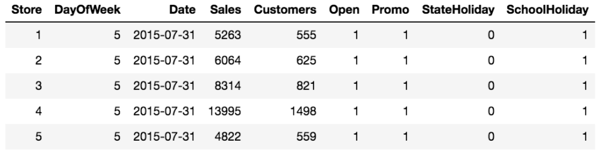

```python
Image('C:\\Users\\Subhasish Das\\Desktop\\SimplyLearn\\Project\\AICapston\\Retail-Datasets\\retaildatasnapshot.png')
```

## Project Task: Week 1

**Exploratory Data Analysis (EDA) and Linear Regression:**

1. Transform the variables by using data manipulation techniques like, One-Hot Encoding
2. Perform an EDA (Exploratory Data Analysis) to see the impact of variables over Sales.
3. Apply Linear Regression to predict the forecast and evaluate different accuracy metrices like RMSE (Root Mean Squared Error) and MAE(Mean Absolute Error) and determine which metric makes more sense. Can there be a better accuracy metric?

   a. Train a single model for all stores, using storeId as a feature.

   b. Train separate model for each store.

   c. Which performs better and Why? [In the first case, parameters are shared and not very free but not in second case]

   d. Try Ensemble of (a) and (b). What are the findings?

   e. Use Regularized Regression. It should perform better in an unseen test set. Any insights??

   f. Open-ended modeling to get possible predictions.

### Code :

## Importing All the library

```python
import numpy as np
import pandas as pd
import seaborn as sns
import matplotlib.pyplot as plt
from sklearn.preprocessing import LabelEncoder
import seaborn as sns
import matplotlib.pyplot as plt
from sklearn.linear_model import LinearRegression,Ridge,Lasso
from sklearn.metrics import mean_squared_error,mean_absolute_error,r2_score
from statsmodels.formula.api import ols
from sklearn.ensemble import RandomForestRegressor
from sklearn.tree import DecisionTreeRegressor
from sklearn.svm import SVR
from sklearn.decomposition import PCA
import xgboost as xgb
from IPython.display import Image
```

# Reading The files

```python
dt_test=pd.read_csv("C:\\Users\\Subhasish Das\\Desktop\\SimplyLearn\\Project\\AICapston\\Retail-Datasets\\test_data.csv")
dt_train=pd.read_csv("C:\\Users\\Subhasish Das\\Desktop\\SimplyLearn\\Project\\AICapston\\Retail-Datasets\\train_data.csv")
dt_hidden=pd.read_csv("C:\\Users\\Subhasish Das\\Desktop\\SimplyLearn\\Project\\AICapston\\Retail-Datasets\\test_data_hidden.csv")
```

```
C:\Users\Subhasish Das\Anaconda3\lib\site-packages\IPython\core\interactiveshell.py:3049: DtypeWarning: Columns (7) have mixed types. Specify dtype option on import or set low_memory=False.
  interactivity=interactivity, compiler=compiler, result=result)
```

```python
dt_train.head()
```

|  | Store | DayOfWeek | Date | Sales | Customers | Open | Promo | StateHoliday | SchoolHoliday |
| --- | --- | --- | --- | --- | --- | --- | --- | --- | --- |
| 0 | 1 | 2 | 2015-06-30 | 5735 | 568 | 1 | 1 | 0 | 0 |
| 1 | 2 | 2 | 2015-06-30 | 9863 | 877 | 1 | 1 | 0 | 0 |
| 2 | 3 | 2 | 2015-06-30 | 13261 | 1072 | 1 | 1 | 0 | 1 |
| 3 | 4 | 2 | 2015-06-30 | 13106 | 1488 | 1 | 1 | 0 | 0 |
| 4 | 5 | 2 | 2015-06-30 | 6635 | 645 | 1 | 1 | 0 | 0 |

```python
dt_test.head()
```

|  | Store | DayOfWeek | Date | Customers | Open | Promo | StateHoliday | SchoolHoliday |
| --- | --- | --- | --- | --- | --- | --- | --- | --- |
| 0 | 1 | 5 | 31-07-2015 | 555 | 1 | 1 | 0 | 1 |
| 1 | 2 | 5 | 31-07-2015 | 625 | 1 | 1 | 0 | 1 |
| 2 | 3 | 5 | 31-07-2015 | 821 | 1 | 1 | 0 | 1 |
| 3 | 4 | 5 | 31-07-2015 | 1498 | 1 | 1 | 0 | 1 |
| 4 | 5 | 5 | 31-07-2015 | 559 | 1 | 1 | 0 | 1 |

```python
dt_hidden.head()
```

|  | Store | DayOfWeek | Date | Sales | Customers | Open | Promo | StateHoliday | SchoolHoliday |
| --- | --- | --- | --- | --- | --- | --- | --- | --- | --- |
| 0 | 1 | 5 | 2015-07-31 | 5263 | 555 | 1 | 1 | 0 | 1 |
| 1 | 2 | 5 | 2015-07-31 | 6064 | 625 | 1 | 1 | 0 | 1 |
| 2 | 3 | 5 | 2015-07-31 | 8314 | 821 | 1 | 1 | 0 | 1 |
| 3 | 4 | 5 | 2015-07-31 | 13995 | 1498 | 1 | 1 | 0 | 1 |
| 4 | 5 | 5 | 2015-07-31 | 4822 | 559 | 1 | 1 | 0 | 1 |

```python
dt_train.shape
```

```
(982644, 9)
```

```python
dt_test.shape
```

```
(34565, 8)
```

```python
dt_hidden.shape
```

```
(34565, 9)
```

```python
dt_merged=pd.concat([dt_train,dt_hidden])
```

```python
dt_merged.head()
```

|  | Store | DayOfWeek | Date | Sales | Customers | Open | Promo | StateHoliday | SchoolHoliday |
| --- | --- | --- | --- | --- | --- | --- | --- | --- | --- |
| 0 | 1 | 2 | 2015-06-30 | 5735 | 568 | 1 | 1 | 0 | 0 |
| 1 | 2 | 2 | 2015-06-30 | 9863 | 877 | 1 | 1 | 0 | 0 |
| 2 | 3 | 2 | 2015-06-30 | 13261 | 1072 | 1 | 1 | 0 | 1 |
| 3 | 4 | 2 | 2015-06-30 | 13106 | 1488 | 1 | 1 | 0 | 0 |
| 4 | 5 | 2 | 2015-06-30 | 6635 | 645 | 1 | 1 | 0 | 0 |

```python
dt_merged.shape
```

```
(1017209, 9)
```

# Variance object and null value checking

```python
zerovar_merged=dt_merged.var()[dt_merged.var()==0].index.values
zerovar_merged
```

```
array([], dtype=object)
```

```python
zerovar_train=dt_train.var()[dt_train.var()==0].index.values
zerovar_train
```

```
array([], dtype=object)
```

```python
zerovar_hidden=dt_hidden.var()[dt_hidden.var()==0].index.values
zerovar_hidden
```

```
array(['StateHoliday'], dtype=object)
```

```python
zerovar_test=dt_test.var()[dt_test.var()==0].index.values
zerovar_test
```

```
array(['StateHoliday'], dtype=object)
```

```python
dt_merged['Date']=pd.to_datetime(dt_merged['Date'])
```

```python
dt_train['Date']=pd.to_datetime(dt_train['Date'])
```

```python
dt_test['Date']=pd.to_datetime(dt_test['Date'])
```

```python
dt_hidden['Date']=pd.to_datetime(dt_hidden['Date'])
```

# Graph Plotting:

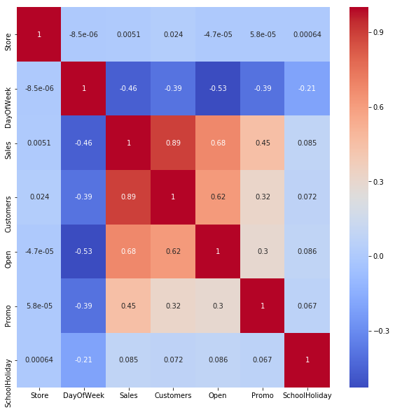

```python
plt.figure(figsize=(10,10))
sns.heatmap(dt_merged.corr(),annot=True,cmap='coolwarm')
```

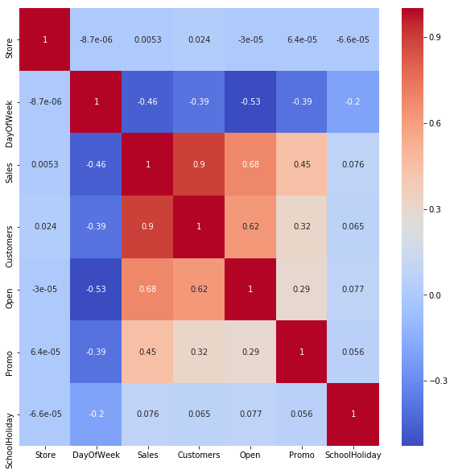

```python
plt.figure(figsize=(10,10))
sns.heatmap(dt_train.corr(),annot=True,cmap='coolwarm')
```

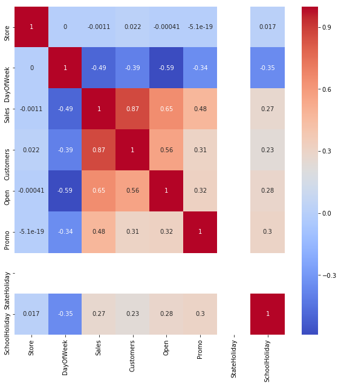

```python
plt.figure(figsize=(10,10))
sns.heatmap(dt_hidden.corr(),annot=True,cmap='coolwarm')
```

#### Observation - 1

> From the above plot we can drop State Holiday column because there is no corelation with that column and Sales column

```python
dt_merged.drop('StateHoliday',inplace=True,axis=1)
dt_train.drop('StateHoliday',inplace=True,axis=1)
dt_test.drop('StateHoliday',inplace=True,axis=1)
dt_hidden.drop('StateHoliday',inplace=True,axis=1)
```

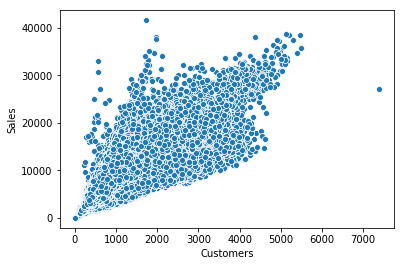

```python
sns.scatterplot(dt_merged['Customers'],dt_merged['Sales'])
```

```python
sns.set_palette('GnBu_d')
sns.set_style('whitegrid')
```

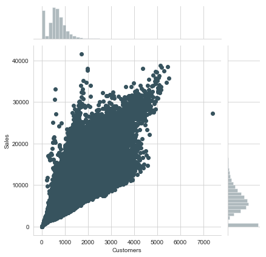

```python
sns.jointplot(x='Customers',y='Sales',data=dt_merged)
```

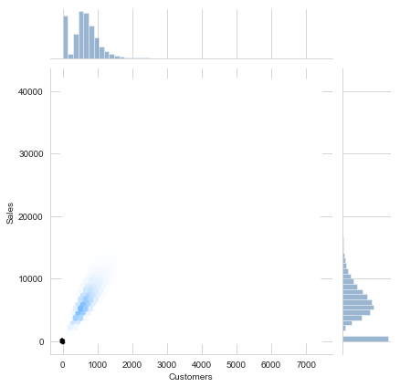

```python
sns.jointplot(x="Customers", y="Sales", kind="hex", color="#00468b",data=dt_merged)
```

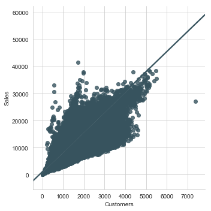

```python
sns.lmplot(x="Customers", y="Sales", data=dt_merged)
```

```python
#sns.pairplot(dt_merged)
```

```python
dt_train.Store.unique()
```

```
array([   1,    2,    3, ..., 1113, 1114, 1115], dtype=int64)
```

```python
dt_test.Store.unique()
```

```
array([   1,    2,    3, ..., 1113, 1114, 1115], dtype=int64)
```

```python
dt_hidden.Store.unique()
```

```
array([   1,    2,    3, ..., 1113, 1114, 1115], dtype=int64)
```

# Linear Regression

```python
options=[1,2,3,911,727,1113,1114,1115]
dt_store_6=dt_train.loc[dt_train['Store'].isin(options)]
```

```python
dt_store_6.head(50)
```

|  | Store | DayOfWeek | Date | Sales | Customers | Open | Promo | SchoolHoliday |
| --- | --- | --- | --- | --- | --- | --- | --- | --- |
| 0 | 1 | 2 | 2015-06-30 | 5735 | 568 | 1 | 1 | 0 |
| 1 | 2 | 2 | 2015-06-30 | 9863 | 877 | 1 | 1 | 0 |
| 2 | 3 | 2 | 2015-06-30 | 13261 | 1072 | 1 | 1 | 1 |
| 726 | 727 | 2 | 2015-06-30 | 6751 | 575 | 1 | 1 | 0 |
| 910 | 911 | 2 | 2015-06-30 | 13936 | 1126 | 1 | 1 | 0 |
| 1112 | 1113 | 2 | 2015-06-30 | 7635 | 721 | 1 | 1 | 0 |
| 1113 | 1114 | 2 | 2015-06-30 | 29714 | 3858 | 1 | 1 | 0 |
| 1114 | 1115 | 2 | 2015-06-30 | 8610 | 520 | 1 | 1 | 0 |
| 1115 | 1 | 1 | 2015-06-29 | 5197 | 541 | 1 | 1 | 0 |
| 1116 | 2 | 1 | 2015-06-29 | 7961 | 734 | 1 | 1 | 0 |
| 1117 | 3 | 1 | 2015-06-29 | 10243 | 817 | 1 | 1 | 1 |
| 1841 | 727 | 1 | 2015-06-29 | 6998 | 601 | 1 | 1 | 0 |
| 2025 | 911 | 1 | 2015-06-29 | 14866 | 1150 | 1 | 1 | 0 |
| 2227 | 1113 | 1 | 2015-06-29 | 8641 | 759 | 1 | 1 | 0 |
| 2228 | 1114 | 1 | 2015-06-29 | 28719 | 3724 | 1 | 1 | 0 |
| 2229 | 1115 | 1 | 2015-06-29 | 11006 | 619 | 1 | 1 | 0 |
| 2230 | 1 | 7 | 2015-06-28 | 0 | 0 | 0 | 0 | 0 |
| 2231 | 2 | 7 | 2015-06-28 | 0 | 0 | 0 | 0 | 0 |
| 2232 | 3 | 7 | 2015-06-28 | 0 | 0 | 0 | 0 | 0 |
| 2956 | 727 | 7 | 2015-06-28 | 0 | 0 | 0 | 0 | 0 |
| 3140 | 911 | 7 | 2015-06-28 | 0 | 0 | 0 | 0 | 0 |
| 3342 | 1113 | 7 | 2015-06-28 | 0 | 0 | 0 | 0 | 0 |
| 3343 | 1114 | 7 | 2015-06-28 | 0 | 0 | 0 | 0 | 0 |
| 3344 | 1115 | 7 | 2015-06-28 | 0 | 0 | 0 | 0 | 0 |
| 3345 | 1 | 6 | 2015-06-27 | 4019 | 463 | 1 | 0 | 0 |
| 3346 | 2 | 6 | 2015-06-27 | 2404 | 303 | 1 | 0 | 0 |
| 3347 | 3 | 6 | 2015-06-27 | 5156 | 641 | 1 | 0 | 0 |
| 4071 | 727 | 6 | 2015-06-27 | 2506 | 263 | 1 | 0 | 0 |
| 4255 | 911 | 6 | 2015-06-27 | 7929 | 709 | 1 | 0 | 0 |
| 4457 | 1113 | 6 | 2015-06-27 | 6346 | 618 | 1 | 0 | 0 |
| 4458 | 1114 | 6 | 2015-06-27 | 21791 | 3643 | 1 | 0 | 0 |
| 4459 | 1115 | 6 | 2015-06-27 | 6676 | 494 | 1 | 0 | 0 |
| 4460 | 1 | 5 | 2015-06-26 | 3317 | 420 | 1 | 0 | 0 |
| 4461 | 2 | 5 | 2015-06-26 | 3953 | 476 | 1 | 0 | 0 |
| 4462 | 3 | 5 | 2015-06-26 | 6222 | 698 | 1 | 0 | 0 |
| 5186 | 727 | 5 | 2015-06-26 | 4816 | 476 | 1 | 0 | 0 |
| 5370 | 911 | 5 | 2015-06-26 | 9279 | 861 | 1 | 0 | 0 |
| 5572 | 1113 | 5 | 2015-06-26 | 5796 | 659 | 1 | 0 | 0 |
| 5573 | 1114 | 5 | 2015-06-26 | 18614 | 3236 | 1 | 0 | 0 |
| 5574 | 1115 | 5 | 2015-06-26 | 5549 | 380 | 1 | 0 | 0 |
| 5575 | 1 | 4 | 2015-06-25 | 3533 | 433 | 1 | 0 | 0 |
| 5576 | 2 | 4 | 2015-06-25 | 4022 | 508 | 1 | 0 | 0 |
| 5577 | 3 | 4 | 2015-06-25 | 5763 | 693 | 1 | 0 | 0 |
| 6301 | 727 | 4 | 2015-06-25 | 3899 | 437 | 1 | 0 | 0 |
| 6485 | 911 | 4 | 2015-06-25 | 7306 | 776 | 1 | 0 | 0 |
| 6687 | 1113 | 4 | 2015-06-25 | 5966 | 711 | 1 | 0 | 0 |
| 6688 | 1114 | 4 | 2015-06-25 | 18782 | 3075 | 1 | 0 | 0 |
| 6689 | 1115 | 4 | 2015-06-25 | 5015 | 334 | 1 | 0 | 0 |
| 6690 | 1 | 3 | 2015-06-24 | 3346 | 414 | 1 | 0 | 0 |
| 6691 | 2 | 3 | 2015-06-24 | 4805 | 654 | 1 | 0 | 0 |

#### Observation - 2

> There is no Co-realtion between Date and sales column hence drpping that column

```python
dt_store_6.drop('Date',axis=1,inplace=True)
dt_test.drop('Date',axis=1,inplace=True)
dt_hidden.drop('Date',axis=1,inplace=True)
dt_train.drop('Date',axis=1,inplace=True)
dt_merged.drop('Date',axis=1,inplace=True)
```

```
C:\Users\Subhasish Das\Anaconda3\lib\site-packages\pandas\core\frame.py:3940: SettingWithCopyWarning:
A value is trying to be set on a copy of a slice from a DataFrame

See the caveats in the documentation: http://pandas.pydata.org/pandas-docs/stable/indexing.html#indexing-view-versus-copy
  errors=errors)
```

```python
x=dt_store_6.drop('Sales',axis=1)
y=dt_store_6['Sales']
```

```python
x_hidd=dt_hidden.drop('Sales',axis=1)
y_hidd=dt_hidden['Sales']
```

```python
lr=LinearRegression()
```

```python
lr.fit(x,y)
```

```
LinearRegression(copy_X=True, fit_intercept=True, n_jobs=None, normalize=False)
```

```python
pred=lr.predict(dt_test)
```

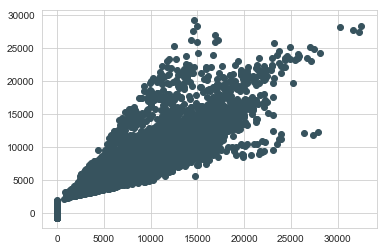

```python
plt.scatter(y_hidd,pred)
```

```python
print('MSE',mean_squared_error(y_hidd,pred))
print('MAE',mean_absolute_error(y_hidd,pred))
print('RMSE',np.sqrt(mean_squared_error(y_hidd,pred)))
print('r2 Square',r2_score(y_hidd,pred))
```

```
MSE 2473720.23592596
MAE 1095.995302236992
RMSE 1572.8064839407166
r2 Square 0.80979333807197
```

```python
test_array=np.array([2,5,625,1,1,1])
```

```python
print(lr.predict(test_array.reshape(1,6)))
```

```
[6283.0507024]
```

```python
ols_model=ols('Store ~ Customers',data=x).fit()
```

```python
ols_model.summary()
```

OLS Regression Results

| Dep. Variable: | Store | R-squared: | 0.090 |
| --- | --- | --- | --- |
| Model: | OLS | Adj. R-squared: | 0.090 |
| Method: | Least Squares | F-statistic: | 718.9 |
| Date: | Thu, 03 Dec 2020 | Prob (F-statistic): | 4.04e-151 |
| Time: | 22:41:37 | Log-Likelihood: | -55243. |
| No. Observations: | 7288 | AIC: | 1.105e+05 |
| Df Residuals: | 7286 | BIC: | 1.105e+05 |
| Df Model: | 1 |  |  |
| Covariance Type: | nonrobust |  |  |

|  | coef | std err | t | P>\|t\| | [0.025 | 0.975] |
| --- | --- | --- | --- | --- | --- | --- |
| Intercept | 489.9167 | 7.453 | 65.732 | 0.000 | 475.306 | 504.527 |
| Customers | 0.1690 | 0.006 | 26.813 | 0.000 | 0.157 | 0.181 |

| Omnibus: | 36259.563 | Durbin-Watson: | 1.267 |
| --- | --- | --- | --- |
| Prob(Omnibus): | 0.000 | Jarque-Bera (JB): | 834.882 |
| Skew: | -0.213 | Prob(JB): | 5.10e-182 |
| Kurtosis: | 1.397 | Cond. No. | 1.59e+03 |

Warnings:  
[1] Standard Errors assume that the covariance matrix of the errors is correctly specified.  
[2] The condition number is large, 1.59e+03. This might indicate that there are  
strong multicollinearity or other numerical problems.

```python
pred_ols=ols_model.predict(dt_test)
```

```python
pred_ols
```

```
0         583.716873
1         595.547524
2         628.673348
3         743.092649
4         584.392910
5         589.463189
6         728.895867
7         630.701460
8         606.026101
9         605.012045
10        698.812210
11        652.503660
12        585.913994
13        609.913315
14        619.377836
```

[output cut: 47 more lines]

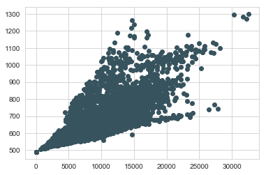

```python
plt.scatter(y_hidd,pred_ols)
```

```python
print('MSE',mean_squared_error(y_hidd,pred_ols))
print('MAE',mean_absolute_error(y_hidd,pred_ols))
print('RMSE',np.sqrt(mean_squared_error(y_hidd,pred_ols)))
print('R2',r2_score(y_hidd,pred_ols))
```

```
MSE 43287582.27848612
MAE 5668.053281759297
RMSE 6579.3299262528335
R2 -2.32842267631926
```

```python
dt_store_1=dt_train.loc[dt_train['Store']==1113]
```

```python
dt_store_1.head()
```

|  | Store | DayOfWeek | Sales | Customers | Open | Promo | SchoolHoliday |
| --- | --- | --- | --- | --- | --- | --- | --- |
| 1112 | 1113 | 2 | 7635 | 721 | 1 | 1 | 0 |
| 2227 | 1113 | 1 | 8641 | 759 | 1 | 1 | 0 |
| 3342 | 1113 | 7 | 0 | 0 | 0 | 0 | 0 |
| 4457 | 1113 | 6 | 6346 | 618 | 1 | 0 | 0 |
| 5572 | 1113 | 5 | 5796 | 659 | 1 | 0 | 0 |

```python
x_1=dt_store_1.drop('Sales',axis=1)
y_1=dt_store_1['Sales']
```

```python
lr_1=LinearRegression()
lr_1.fit(x_1,y_1)
```

```
LinearRegression(copy_X=True, fit_intercept=True, n_jobs=None, normalize=False)
```

```python
pred_1=lr_1.predict(dt_test)
```

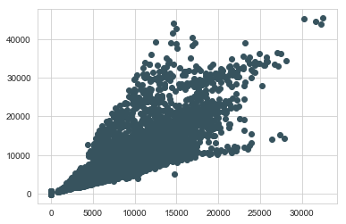

```python
plt.scatter(y_hidd,pred_1)
```

```python
print('MAE',mean_absolute_error(y_hidd,pred_1))
print('MSE',mean_squared_error(y_hidd,pred_1))
print('RMSE',np.sqrt(mean_squared_error(y_hidd,pred_1)))
print('R square',r2_score(y_hidd,pred_1))
```

```
MAE 1234.0973611761663
MSE 4256488.2724080235
RMSE 2063.125849871506
R square 0.6727146368160406
```

```python
test_array=np.array([2,5,625,1,1,1])
print(lr.predict(test_array.reshape(1,6)))
```

```
[6283.0507024]
```

# Ensemble Modeling

```python
from sklearn.ensemble import VotingClassifier
estimator=[('lr', lr),('lr_1', lr_1)]
ensamble=VotingClassifier(estimator,voting='hard')
x = x.to_numpy(dtype ='float32')
y = y.to_numpy(dtype ='float32')
ensamble.fit(x,y)
```

```
VotingClassifier(estimators=[('lr',
                              LinearRegression(copy_X=True, fit_intercept=True,
                                               n_jobs=None, normalize=False)),
                             ('lr_1',
                              LinearRegression(copy_X=True, fit_intercept=True,
                                               n_jobs=None, normalize=False))],
                 flatten_transform=True, n_jobs=None, voting='hard',
                 weights=None)
```

# Regularized Regression

```python
ridge = Ridge(alpha = 0.01)
ridge.fit(x,y)
```

```
Ridge(alpha=0.01, copy_X=True, fit_intercept=True, max_iter=None,
      normalize=False, random_state=None, solver='auto', tol=0.001)
```

```python
y_pred_ri=ridge.predict(dt_test)
```

```python
y_pred_ri
```

```
array([ 5891.90817201,  6283.03858256,  7376.40880406, ...,
        8345.08246458, 25166.39511847,  6546.89064705])
```

```python
test_array=np.array([2,5,625,1,1,1])
```

```python
print(ridge.predict(test_array.reshape(1,6)))
```

```
[6283.03858256]
```

```python
print('MAE',mean_absolute_error(y_hidd,y_pred_ri))
print('MSE',mean_squared_error(y_hidd,y_pred_ri))
print('RMSE',np.sqrt(mean_squared_error(y_hidd,y_pred_ri)))
print('R2 square',r2_score(y_hidd,y_pred_ri))
```

```
MAE 1095.9942820818296
MSE 2473719.1037853826
RMSE 1572.8061240297172
R2 square 0.8097934222674273
```

```python
ridge_1 = Ridge(alpha = 0.01)
ridge_1.fit(x_1,y_1)
```

```
Ridge(alpha=0.01, copy_X=True, fit_intercept=True, max_iter=None,
      normalize=False, random_state=None, solver='auto', tol=0.001)
```

```python
y_pred_ridge_1=ridge_1.predict(dt_test)
```

```python
test_array=np.array([2,5,625,1,1,1])
print(ridge_1.predict(test_array.reshape(1,6)))
```

```
[6208.96788906]
```

```python
print('MAE',mean_absolute_error(y_hidd,y_pred_ridge_1))
print('MSE',mean_squared_error(y_hidd,y_pred_ridge_1))
print('RMSE',np.sqrt(mean_squared_error(y_hidd,y_pred_ridge_1)))
print('R2 square',r2_score(y_hidd,y_pred_ridge_1))
```

```
MAE 1234.0695055247127
MSE 4256250.9218327785
RMSE 2063.0683269908386
R2 square 0.6727328820098898
```

```python
lasso = Lasso(alpha=0.01)
lasso.fit(x,y)
```

```
C:\Users\Subhasish Das\Anaconda3\lib\site-packages\sklearn\linear_model\coordinate_descent.py:475: ConvergenceWarning: Objective did not converge. You might want to increase the number of iterations. Duality gap: 4375567872.0, tolerance: 24258360.0
  positive)
```

```
Lasso(alpha=0.01, copy_X=True, fit_intercept=True, max_iter=1000,
      normalize=False, positive=False, precompute=False, random_state=None,
      selection='cyclic', tol=0.0001, warm_start=False)
```

```python
y_pred_lass=lasso.predict(dt_test)
```

```python
print('MAE',mean_absolute_error(y_hidd,y_pred_lass))
print('MSE',mean_squared_error(y_hidd,y_pred_lass))
print('RMSE',np.sqrt(mean_squared_error(y_hidd,y_pred_lass)))
print('R2 square',r2_score(y_hidd,y_pred_lass))
```

```
MAE 1095.9924974540925
MSE 2473716.0473223394
RMSE 1572.805152370229
R2 square 0.8097936572817321
```

```python
lasso_1 = Lasso(alpha=0.01)
lasso_1.fit(x_1,y_1)
```

```
Lasso(alpha=0.01, copy_X=True, fit_intercept=True, max_iter=1000,
      normalize=False, positive=False, precompute=False, random_state=None,
      selection='cyclic', tol=0.0001, warm_start=False)
```

```python
type(dt_test)
```

```
pandas.core.frame.DataFrame
```

```python
y_pred_lass_1=lasso_1.predict(dt_test)
```

```python
print('MAE',mean_absolute_error(y_hidd,y_pred_lass_1))
print('MSE',mean_squared_error(y_hidd,y_pred_lass_1))
print('RMSE',np.sqrt(mean_squared_error(y_hidd,y_pred_lass_1)))
print('R2 square',r2_score(y_hidd,y_pred_lass_1))
```

```
MAE 1234.0371357595768
MSE 4255977.968451111
RMSE 2063.0021736418776
R2 square 0.6727538696509394
```

# Open-ended model

```python
model_xgb=xgb.XGBRegressor(object='reg:linear',learning_rate=0.1)
```

```python
model_xgb.fit(x,y)
```

```
XGBRegressor(base_score=0.5, booster=None, colsample_bylevel=1,
             colsample_bynode=1, colsample_bytree=1, gamma=0, gpu_id=-1,
             importance_type='gain', interaction_constraints=None,
             learning_rate=0.1, max_delta_step=0, max_depth=6,
             min_child_weight=1, missing=nan, monotone_constraints=None,
             n_estimators=100, n_jobs=0, num_parallel_tree=1,
             object='reg:linear', objective='reg:squarederror', random_state=0,
             reg_alpha=0, reg_lambda=1, scale_pos_weight=1, subsample=1,
             tree_method=None, validate_parameters=False, verbosity=None)
```

```python
pre_xgb=model_xgb.predict(dt_test)
```

```python
print('MAE',mean_absolute_error(y_hidd,pre_xgb))
print('MSE',mean_squared_error(y_hidd,pre_xgb))
print('RMSE',np.sqrt(mean_squared_error(y_hidd,pre_xgb)))
print('R2 square',r2_score(y_hidd,pre_xgb))
```

```
MAE 1238.8999
MSE 3435889.2
RMSE 1853.6152
R2 square 0.7358112388138192
```

```python
model_xgb_1=xgb.XGBRegressor(object='reg:linear',learning_rate=0.1)
```

```python
model_xgb_1.fit(x_1,y_1)
pre_xgb_1=model_xgb_1.predict(dt_test)
```

```python
print('MAE',mean_absolute_error(y_hidd,pre_xgb_1))
print('MSE',mean_squared_error(y_hidd,pre_xgb_1))
print('RMSE',np.sqrt(mean_squared_error(y_hidd,pre_xgb_1)))
print('R2 square',r2_score(y_hidd,pre_xgb_1))
```

```
MAE 1156.8569
MSE 2781187.8
RMSE 1667.6893
R2 square 0.7861518780225876
```

```python
from sklearn.model_selection import GridSearchCV, cross_val_score, StratifiedKFold,learning_curve
```

```python
kfold = StratifiedKFold(n_splits=10)
```

```python
classifiers = []
random_state = 2
classifiers.append(LinearRegression())
classifiers.append(Ridge())
classifiers.append(Lasso())
classifiers.append((model_xgb))
```

[output not shown]

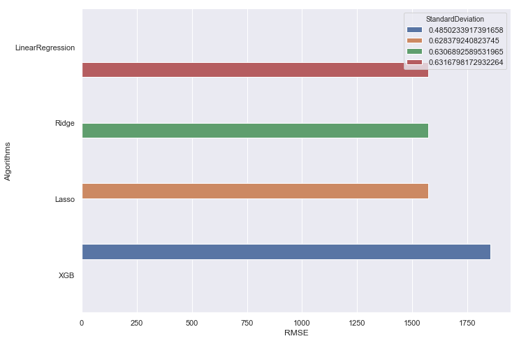

```python
cv_results = []
cv_RMSE=[]

for classifier in classifiers:
    cv_results.append(cross_val_score(classifier,x,y=y,cv=kfold,n_jobs=4))
    classifier.fit(x,y)
    pred=classifier.predict(dt_test)
    cv_RMSE.append(np.sqrt(mean_squared_error(y_hidd,pred)))
    #cv_results.append(np.sqrt(mean_squared_error(y_hidd,pred)))
cv_means = []
cv_std = []



for cv_result in cv_results:
    cv_means.append(cv_result.mean())
    cv_std.append(cv_result.std())



cv_results = pd.DataFrame({'CrossValMeans':cv_means,'StandardDeviation':cv_std,'RMSE':cv_RMSE,
                           'Algorithms':['LinearRegression','Ridge','Lasso','XGB']})

g = sns.barplot(x='RMSE',y='Algorithms',hue='StandardDeviation',data=cv_results)
```

```python
cv_results.head()
```

|  | CrossValMeans | StandardDeviation | RMSE | Algorithms |
| --- | --- | --- | --- | --- |
| 0 | 0.320192 | 0.631680 | 1572.806484 | LinearRegression |
| 1 | 0.320582 | 0.630689 | 1572.789748 | Ridge |
| 2 | 0.321523 | 0.628379 | 1572.682163 | Lasso |
| 3 | 0.593984 | 0.485023 | 1853.615234 | XGB |

#### Observation - 3

```python
classifiers = []
random_state = 2
classifiers.append(LinearRegression())
classifiers.append(Ridge())
classifiers.append(Lasso())
classifiers.append((model_xgb_1))
```

[output not shown]

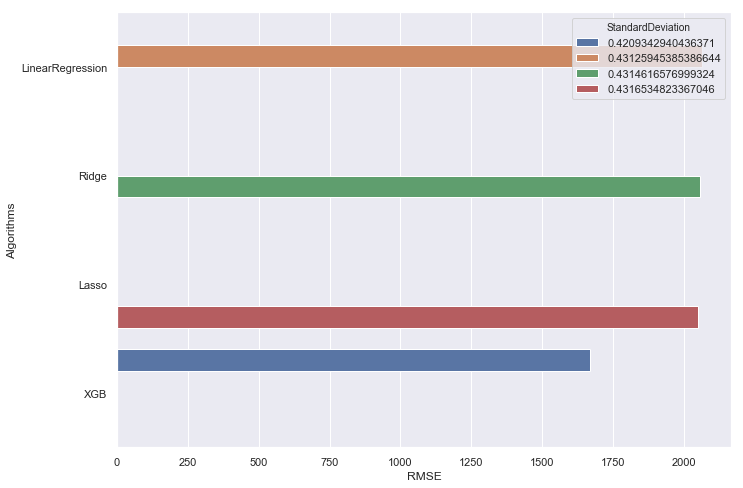

```python
cv_results = []
cv_RMSE=[]

for classifier in classifiers:
    cv_results.append(cross_val_score(classifier,x_1,y=y_1,cv=kfold,n_jobs=4))
    classifier.fit(x_1,y_1)
    pred=classifier.predict(dt_test)
    cv_RMSE.append(np.sqrt(mean_squared_error(y_hidd,pred)))
    #cv_results.append(np.sqrt(mean_squared_error(y_hidd,pred)))
cv_means = []
cv_std = []



for cv_result in cv_results:
    cv_means.append(cv_result.mean())
    cv_std.append(cv_result.std())



cv_results = pd.DataFrame({'CrossValMeans':cv_means,'StandardDeviation':cv_std,'RMSE':cv_RMSE,
                           'Algorithms':['LinearRegression','Ridge','Lasso','XGB']})

g = sns.barplot(x='RMSE',y='Algorithms',hue='StandardDeviation',data=cv_results)
```

```python
cv_results.head()
```

|  | CrossValMeans | StandardDeviation | RMSE | Algorithms |
| --- | --- | --- | --- | --- |
| 0 | 0.281415 | 0.431259 | 2063.125850 | LinearRegression |
| 1 | 0.281567 | 0.431462 | 2057.703141 | Ridge |
| 2 | 0.281712 | 0.431653 | 2050.820057 | Lasso |
| 3 | 0.272783 | 0.420934 | 1667.689331 | XGB |

#### Observation - 4

> As we know Lower value of RMSE Score are indicative of a better model  
> After Applying Above algorithm for 1 stores I find that XGB giving better result

## Project Task: Week 2

**Other Regression Techniques:**

1. When store is closed, **`sales = 0`**. Can this insight be used for Data Cleaning? Perform this and retrain the model. Any benefits of this step?
2. Use Non-Linear Regressors like Random Forest or other Tree-based Regressors.

   a. Train a single model for all stores, where storeId can be a feature.

   b. Train separate models for each store.

   **Note:** Dimensional Reduction *techniques* like, `"PCA"` and `"Tree’s Hyperparameter Tuning"` will be required. **Cross-validate** to find the best parameters. Infer the performance of both the models.
3. Compare the performance of Linear Model and Non-Linear Model from the previous observations. Which performs better and why?
4. Train a Time-series model on the data taking time as the only feature. This will be a store-level training.

   a. Identify yearly trends and seasonal months

### Code :

# Non-Linear Regressors

```python
dt_open_tr=dt_train.loc[dt_train['Open']==1]
```

```python
dt_open_test=dt_test.loc[dt_test['Open']==1]
```

```python
dt_open_hidd=dt_hidden.loc[dt_hidden['Open']==1]
```

```python
x_op_tr=dt_open_tr.drop('Sales',axis=1)
y_op_tr=dt_open_tr['Sales']
```

```python
x_op_hidd=dt_open_hidd.drop('Sales',axis=1)
y_op_hidd=dt_open_hidd['Sales']
```

```python
options=[1103,1104,1105,1106,1107,1108]
dttr_op_st=dt_open_tr.loc[dt_open_tr['Store'].isin(options)]
```

```python
x_rand=dttr_op_st.drop('Sales',axis=1)
y_rand=dttr_op_st['Sales']
```

```python
lr_op=LinearRegression()
lr_op.fit(x_rand,y_rand)
lr_op_pred=lr_op.predict(dt_open_test)
```

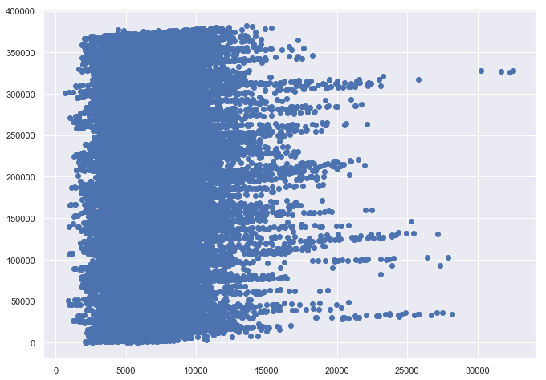

```python
plt.scatter(y_op_hidd,lr_op_pred)
```

```python
print('MAE',mean_absolute_error(y_op_hidd,lr_op_pred))
print('MSE',mean_squared_error(y_op_hidd,lr_op_pred))
print('RMSE',np.sqrt(mean_squared_error(y_op_hidd,lr_op_pred)))
print('R2 score',r2_score(y_op_hidd,lr_op_pred))
```

```
MAE 181987.49650225232
MSE 44462081186.10252
RMSE 210860.33573458646
R2 score -5152.866951992394
```

```python
model_rand=RandomForestRegressor()
model_rand.fit(x_rand,y_rand)
rand_pred=model_rand.predict(dt_open_test)
```

```
C:\Users\Subhasish Das\Anaconda3\lib\site-packages\sklearn\ensemble\forest.py:245: FutureWarning: The default value of n_estimators will change from 10 in version 0.20 to 100 in 0.22.
  "10 in version 0.20 to 100 in 0.22.", FutureWarning)
```

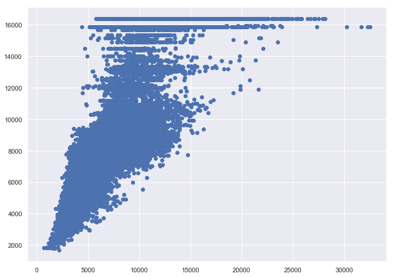

```python
plt.scatter(y_op_hidd,rand_pred)
```

```python
print('MAE',mean_absolute_error(y_op_hidd,rand_pred))
print('MSE',mean_squared_error(y_op_hidd,rand_pred))
print('RMSE',np.sqrt(mean_squared_error(y_op_hidd,rand_pred)))
print('R2 score',r2_score(y_op_hidd,rand_pred))
```

```
MAE 1740.814333720326
MSE 4905942.015674553
RMSE 2214.9361199986224
R2 score 0.4313227867777092
```

```python
dttr_op_st_1=dt_open_tr.loc[dt_open_tr['Store']==1105]
```

```python
x_rand_1=dttr_op_st_1.drop('Sales',axis=1)
y_rand_1=dttr_op_st_1['Sales']
```

```python
model_rand_1=RandomForestRegressor()
model_rand_1.fit(x_rand_1,y_rand_1)
rand_pred_1=model_rand_1.predict(dt_open_test)
```

```
C:\Users\Subhasish Das\Anaconda3\lib\site-packages\sklearn\ensemble\forest.py:245: FutureWarning: The default value of n_estimators will change from 10 in version 0.20 to 100 in 0.22.
  "10 in version 0.20 to 100 in 0.22.", FutureWarning)
```

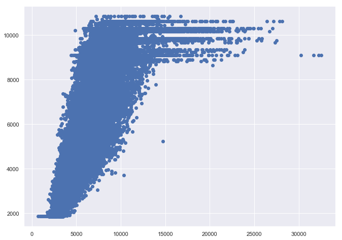

```python
plt.scatter(y_op_hidd,rand_pred_1)
```

```python
print('MAE',mean_absolute_error(y_op_hidd,rand_pred_1))
print('MSE',mean_squared_error(y_op_hidd,rand_pred_1))
print('RMSE',np.sqrt(mean_squared_error(y_op_hidd,rand_pred_1)))
print('R2 score',r2_score(y_op_hidd,rand_pred_1))
```

```
MAE 1434.685188198927
MSE 4118538.083269212
RMSE 2029.4181637280208
R2 score 0.5225955071910127
```

```python
svr=SVR()
svr.fit(x_rand,y_rand)
model_svr=svr.predict(dt_open_test)
```

```
C:\Users\Subhasish Das\Anaconda3\lib\site-packages\sklearn\svm\base.py:193: FutureWarning: The default value of gamma will change from 'auto' to 'scale' in version 0.22 to account better for unscaled features. Set gamma explicitly to 'auto' or 'scale' to avoid this warning.
  "avoid this warning.", FutureWarning)
```

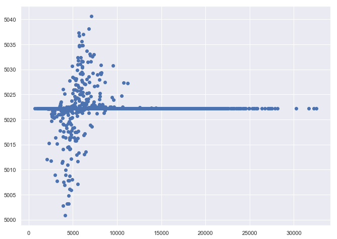

```python
plt.scatter(y_op_hidd,model_svr)
```

```python
print('MAE',mean_absolute_error(y_op_hidd,model_svr))
print('MSE',mean_squared_error(y_op_hidd,model_svr))
print('RMSE',np.sqrt(mean_squared_error(y_op_hidd,model_svr)))
print('R2 score',r2_score(y_op_hidd,model_svr))
```

```
MAE 2516.181928169334
MSE 12671531.06900608
RMSE 3559.7094079441486
R2 score -0.4688332949225138
```

```python
svr1=SVR()
svr1.fit(x_rand_1,y_rand_1)
model_svr_1=svr1.predict(dt_open_test)
```

```
C:\Users\Subhasish Das\Anaconda3\lib\site-packages\sklearn\svm\base.py:193: FutureWarning: The default value of gamma will change from 'auto' to 'scale' in version 0.22 to account better for unscaled features. Set gamma explicitly to 'auto' or 'scale' to avoid this warning.
  "avoid this warning.", FutureWarning)
```

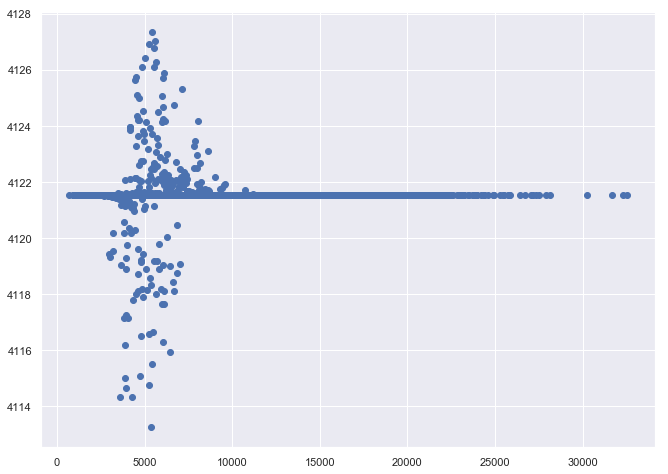

```python
plt.scatter(y_op_hidd,model_svr_1)
```

```python
print('MAE',mean_absolute_error(y_op_hidd,model_svr_1))
print('MSE',mean_squared_error(y_op_hidd,model_svr_1))
print('RMSE',np.sqrt(mean_squared_error(y_op_hidd,model_svr_1)))
print('R2 score',r2_score(y_op_hidd,model_svr_1))
```

```
MAE 3099.7697255526336
MSE 17105470.11413226
RMSE 4135.87597905598
R2 score -0.9827978081034072
```

```python
destree=DecisionTreeRegressor()
destree.fit(x_rand,y_rand)
model_destree=destree.predict(dt_open_test)
```

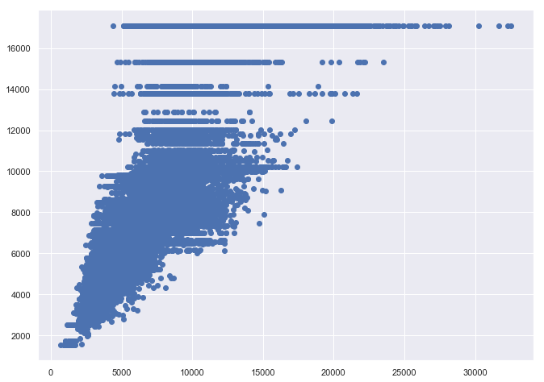

```python
plt.scatter(y_op_hidd,model_destree)
```

```python
print('MAE',mean_absolute_error(y_op_hidd,model_destree))
print('MSE',mean_squared_error(y_op_hidd,model_destree))
print('RMSE',np.sqrt(mean_squared_error(y_op_hidd,model_destree)))
print('R2 score',r2_score(y_op_hidd,model_destree))
```

```
MAE 1887.3093083344374
MSE 6210551.426142102
RMSE 2492.097796263642
R2 score 0.28009767210699443
```

```python
destree1=DecisionTreeRegressor()
destree1.fit(x_rand_1,y_rand_1)
model_destree_1=destree1.predict(dt_open_test)
```

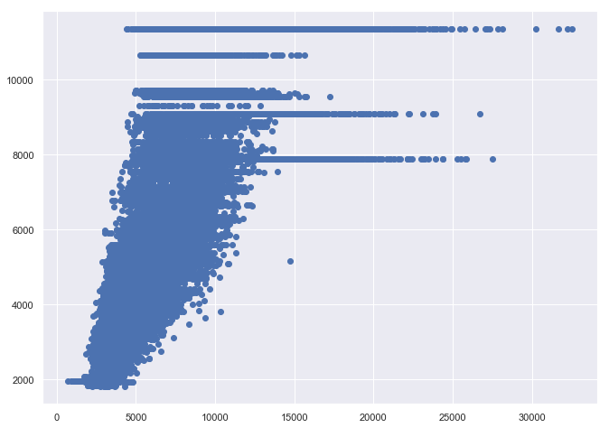

```python
plt.scatter(y_op_hidd,model_destree_1)
```

```python
print('MAE',mean_absolute_error(y_op_hidd,model_destree_1))
print('MSE',mean_squared_error(y_op_hidd,model_destree_1))
print('RMSE',np.sqrt(mean_squared_error(y_op_hidd,model_destree_1)))
print('R2 score',r2_score(y_op_hidd,model_destree_1))
```

```
MAE 1562.303928713396
MSE 4877447.499970555
RMSE 2208.494396635535
R2 score 0.4346257572838619
```

```python
kfold = StratifiedKFold(n_splits=5)
```

```python
classifiers = []
random_state = 2
classifiers.append(LinearRegression())
classifiers.append(RandomForestRegressor())
classifiers.append(SVR())
```

[output not shown]

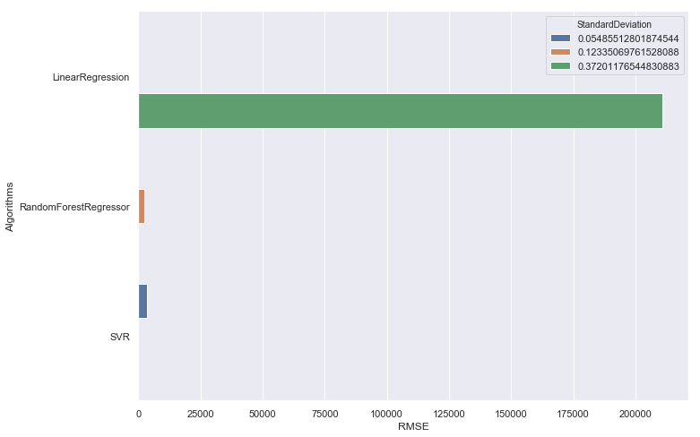

```python
cv_results = []
cv_RMSE=[]

for classifier in classifiers:
    cv_results.append(cross_val_score(classifier,x_rand,y=y_rand,cv=kfold,n_jobs=4))
    classifier.fit(x_rand,y_rand)
    pred=classifier.predict(dt_open_test)
    cv_RMSE.append(np.sqrt(mean_squared_error(y_op_hidd,pred)))
    #cv_results.append(np.sqrt(mean_squared_error(y_hidd,pred)))
cv_means = []
cv_std = []



for cv_result in cv_results:
    cv_means.append(cv_result.mean())
    cv_std.append(cv_result.std())



cv_results = pd.DataFrame({'CrossValMeans':cv_means,'StandardDeviation':cv_std,'RMSE':cv_RMSE,
                           'Algorithms':['LinearRegression','RandomForestRegressor','SVR']})

g = sns.barplot(x='RMSE',y='Algorithms',hue='StandardDeviation',data=cv_results)
```

```python
cv_results.head()
```

|  | CrossValMeans | StandardDeviation | RMSE | Algorithms |
| --- | --- | --- | --- | --- |
| 0 | 0.384392 | 0.372012 | 210860.335735 | LinearRegression |
| 1 | 0.800761 | 0.123351 | 2279.183494 | RandomForestRegressor |
| 2 | -0.079628 | 0.054855 | 3559.709408 | SVR |

###### Observation - 5

> As we know Lower value of RMSE Score are indicative of a better model  
> After Applying Above algorithm for 6 stores I find that RandomForestRegressor giving better result

[output not shown]

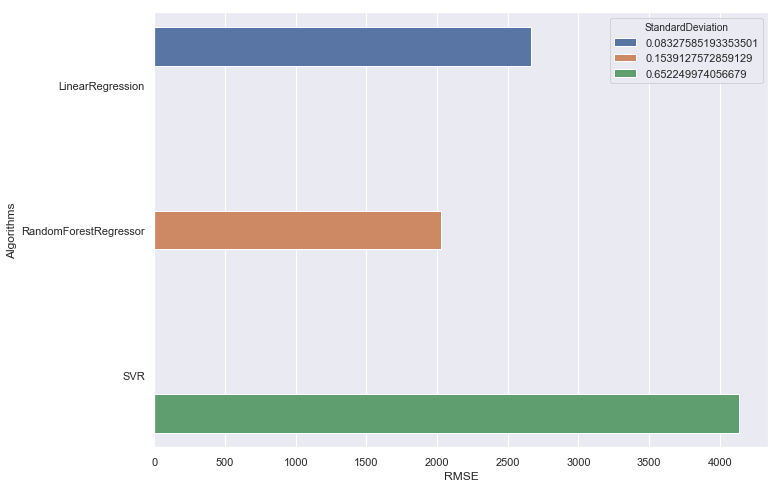

```python
cv_results = []
cv_RMSE=[]

for classifier in classifiers:
    cv_results.append(cross_val_score(classifier,x_rand_1,y=y_rand_1,cv=kfold,n_jobs=4))
    classifier.fit(x_rand_1,y_rand_1)
    pred=classifier.predict(dt_open_test)
    cv_RMSE.append(np.sqrt(mean_squared_error(y_op_hidd,pred)))
    #cv_results.append(np.sqrt(mean_squared_error(y_hidd,pred)))
cv_means = []
cv_std = []



for cv_result in cv_results:
    cv_means.append(cv_result.mean())
    cv_std.append(cv_result.std())



cv_results = pd.DataFrame({'CrossValMeans':cv_means,'StandardDeviation':cv_std,'RMSE':cv_RMSE,
                           'Algorithms':['LinearRegression','RandomForestRegressor','SVR']})

g = sns.barplot(x='RMSE',y='Algorithms',hue='StandardDeviation',data=cv_results)
```

```python
cv_results.head()
```

|  | CrossValMeans | StandardDeviation | RMSE | Algorithms |
| --- | --- | --- | --- | --- |
| 0 | 0.869745 | 0.083276 | 2666.453214 | LinearRegression |
| 1 | 0.780454 | 0.153913 | 2027.978640 | RandomForestRegressor |
| 2 | -0.610758 | 0.652250 | 4135.875979 | SVR |

###### Observation - 6

> As we know Lower value of RMSE Score are indicative of a better model  
> After Applying Above algorithm for 1 stores I find that RandomForestRegressor giving better result

```python
pca=PCA(0.20,svd_solver='full')
```

```python
pca.fit(x_rand)
```

```
PCA(copy=True, iterated_power='auto', n_components=0.2, random_state=None,
    svd_solver='full', tol=0.0, whiten=False)
```

```python
pca.n_components_
```

```
1
```

```python
pca.explained_variance_ratio_
```

```
array([0.99980387])
```

```python
pca_x=pd.DataFrame(pca.transform(x_rand))
```

```python
pca_test=PCA(0.20,svd_solver='full')
```

```python
pca_test.fit(dt_open_test)
```

```
PCA(copy=True, iterated_power='auto', n_components=0.2, random_state=None,
    svd_solver='full', tol=0.0, whiten=False)
```

```python
pca_test.n_components_
```

```
1
```

```python
pca_test.explained_variance_
```

```
array([148331.14999898])
```

```python
pca_xtest=pd.DataFrame(pca_test.transform(dt_open_test))
```

```python
lr_pca=LinearRegression()
lr_pca.fit(pca_x,y_rand)
pca_predict=lr_pca.predict(pca_xtest)
```

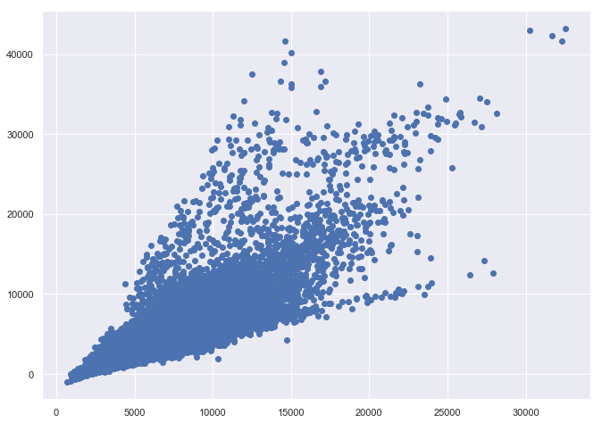

```python
plt.scatter(y_op_hidd,pca_predict)
```

```python
print('MAE',mean_absolute_error(y_op_hidd,pca_predict))
print('MSE',mean_squared_error(y_op_hidd,pca_predict))
print('RMSE',np.sqrt(mean_squared_error(y_op_hidd,pca_predict)))
print('R2 score',r2_score(y_op_hidd,pca_predict))
```

```
MAE 2249.989462609435
MSE 8076219.476681866
RMSE 2841.869011175896
R2 score 0.06383687970687524
```

```python
rand_pca=RandomForestRegressor()
rand_pca.fit(pca_x,y_rand)
rand_predict=rand_pca.predict(pca_xtest)
```

```
C:\Users\Subhasish Das\Anaconda3\lib\site-packages\sklearn\ensemble\forest.py:245: FutureWarning: The default value of n_estimators will change from 10 in version 0.20 to 100 in 0.22.
  "10 in version 0.20 to 100 in 0.22.", FutureWarning)
```

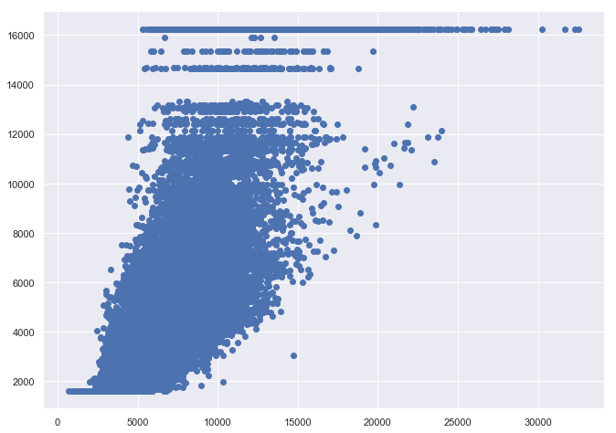

```python
plt.scatter(y_op_hidd,rand_predict)
```

```python
print('MAE',mean_absolute_error(y_op_hidd,rand_predict))
print('MSE',mean_squared_error(y_op_hidd,rand_predict))
print('RMSE',np.sqrt(mean_squared_error(y_op_hidd,rand_predict)))
print('R2 score',r2_score(y_op_hidd,rand_predict))
```

```
MAE 2251.4418579270964
MSE 7492236.256666392
RMSE 2737.194961391386
R2 score 0.131529883225042
```

```python
svr_pca=SVR()
svr_pca.fit(pca_x,y_rand)
svr_predict=svr_pca.predict(pca_xtest)
```

```
C:\Users\Subhasish Das\Anaconda3\lib\site-packages\sklearn\svm\base.py:193: FutureWarning: The default value of gamma will change from 'auto' to 'scale' in version 0.22 to account better for unscaled features. Set gamma explicitly to 'auto' or 'scale' to avoid this warning.
  "avoid this warning.", FutureWarning)
```

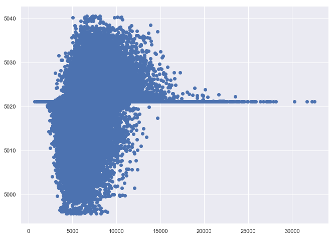

```python
plt.scatter(y_op_hidd,svr_predict)
```

```python
print('MAE',mean_absolute_error(y_op_hidd,svr_predict))
print('MSE',mean_squared_error(y_op_hidd,svr_predict))
print('RMSE',np.sqrt(mean_squared_error(y_op_hidd,svr_predict)))
print('R2 score',r2_score(y_op_hidd,svr_predict))
```

```
MAE 2516.8218002330286
MSE 12672357.422472443
RMSE 3559.825476406455
R2 score -0.4689290825174115
```

```python
classifiers = []
random_state = 2
classifiers.append(LinearRegression())
classifiers.append(RandomForestRegressor())
classifiers.append(SVR())
```

[output not shown]

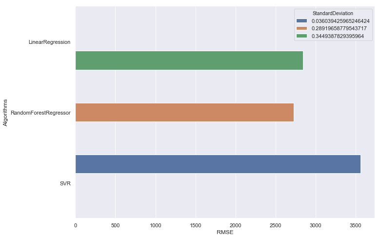

```python
cv_results = []
cv_RMSE=[]

for classifier in classifiers:
    cv_results.append(cross_val_score(classifier,pca_x,y=y_rand,cv=kfold,n_jobs=4))
    classifier.fit(pca_x,y_rand)
    pred=classifier.predict(pca_xtest)
    cv_RMSE.append(np.sqrt(mean_squared_error(y_op_hidd,pred)))
    #cv_results.append(np.sqrt(mean_squared_error(y_hidd,pred)))
cv_means = []
cv_std = []



for cv_result in cv_results:
    cv_means.append(cv_result.mean())
    cv_std.append(cv_result.std())



cv_results = pd.DataFrame({'CrossValMeans':cv_means,'StandardDeviation':cv_std,'RMSE':cv_RMSE,
                           'Algorithms':['LinearRegression','RandomForestRegressor','SVR']})

g = sns.barplot(x='RMSE',y='Algorithms',hue='StandardDeviation',data=cv_results)
```

```python
cv_results.head()
```

|  | CrossValMeans | StandardDeviation | RMSE | Algorithms |
| --- | --- | --- | --- | --- |
| 0 | 0.285974 | 0.344939 | 2841.869011 | LinearRegression |
| 1 | 0.372645 | 0.289197 | 2724.681785 | RandomForestRegressor |
| 2 | -0.049102 | 0.036039 | 3559.825476 | SVR |

###### Observation - 7

> As we know Lower value of RMSE Score are indicative of a better model  
> After Applying PCA for Above algorithm for 6 stores I find that RandomForestRegressor giving better result